# eda final

# Intro

First Lets see what data says about unrelated variable(to be predicted variable).

```r
base_folder <- "/home/amirsalar/Diabetes-R/" # change this:)
data_folder <- paste0(base_folder, "data/")
output_folder <- paste0(base_folder, "output/")

diabetes_012_path <- paste0(data_folder,"diabetes_012_health_indicators_BRFSS2015.csv")
diabetes_binary_5050_path <- paste0(data_folder, "diabetes_binary_5050split_health_indicators_BRFSS2015.csv")
diabetes_binary_path <- paste0(data_folder, "diabetes_binary_health_indicators_BRFSS2015.csv")


library(data.table)
library(ggplot2)
library(readxl)
```

## Data

Let’s have a look at data summery to see what we got!

```r
dt_5050 <- data.table(read.csv(diabetes_binary_5050_path))

summary(dt_5050)
```

```
##  Diabetes_binary     HighBP          HighChol        CholCheck
##  Min.   :0.0     Min.   :0.0000   Min.   :0.0000   Min.   :0.0000
##  1st Qu.:0.0     1st Qu.:0.0000   1st Qu.:0.0000   1st Qu.:1.0000
##  Median :0.5     Median :1.0000   Median :1.0000   Median :1.0000
##  Mean   :0.5     Mean   :0.5635   Mean   :0.5257   Mean   :0.9753
##  3rd Qu.:1.0     3rd Qu.:1.0000   3rd Qu.:1.0000   3rd Qu.:1.0000
##  Max.   :1.0     Max.   :1.0000   Max.   :1.0000   Max.   :1.0000
##       BMI            Smoker           Stroke        HeartDiseaseorAttack
##  Min.   :12.00   Min.   :0.0000   Min.   :0.00000   Min.   :0.0000
##  1st Qu.:25.00   1st Qu.:0.0000   1st Qu.:0.00000   1st Qu.:0.0000
##  Median :29.00   Median :0.0000   Median :0.00000   Median :0.0000
##  Mean   :29.86   Mean   :0.4753   Mean   :0.06217   Mean   :0.1478
##  3rd Qu.:33.00   3rd Qu.:1.0000   3rd Qu.:0.00000   3rd Qu.:0.0000
##  Max.   :98.00   Max.   :1.0000   Max.   :1.00000   Max.   :1.0000
##   PhysActivity       Fruits          Veggies       HvyAlcoholConsump
##  Min.   :0.000   Min.   :0.0000   Min.   :0.0000   Min.   :0.00000
##  1st Qu.:0.000   1st Qu.:0.0000   1st Qu.:1.0000   1st Qu.:0.00000
##  Median :1.000   Median :1.0000   Median :1.0000   Median :0.00000
##  Mean   :0.703   Mean   :0.6118   Mean   :0.7888   Mean   :0.04272
##  3rd Qu.:1.000   3rd Qu.:1.0000   3rd Qu.:1.0000   3rd Qu.:0.00000
##  Max.   :1.000   Max.   :1.0000   Max.   :1.0000   Max.   :1.00000
##  AnyHealthcare    NoDocbcCost         GenHlth         MentHlth
##  Min.   :0.000   Min.   :0.00000   Min.   :1.000   Min.   : 0.000
##  1st Qu.:1.000   1st Qu.:0.00000   1st Qu.:2.000   1st Qu.: 0.000
##  Median :1.000   Median :0.00000   Median :3.000   Median : 0.000
##  Mean   :0.955   Mean   :0.09391   Mean   :2.837   Mean   : 3.752
##  3rd Qu.:1.000   3rd Qu.:0.00000   3rd Qu.:4.000   3rd Qu.: 2.000
##  Max.   :1.000   Max.   :1.00000   Max.   :5.000   Max.   :30.000
##     PhysHlth        DiffWalk           Sex             Age
##  Min.   : 0.00   Min.   :0.0000   Min.   :0.000   Min.   : 1.000
##  1st Qu.: 0.00   1st Qu.:0.0000   1st Qu.:0.000   1st Qu.: 7.000
##  Median : 0.00   Median :0.0000   Median :0.000   Median : 9.000
##  Mean   : 5.81   Mean   :0.2527   Mean   :0.457   Mean   : 8.584
##  3rd Qu.: 6.00   3rd Qu.:1.0000   3rd Qu.:1.000   3rd Qu.:11.000
##  Max.   :30.00   Max.   :1.0000   Max.   :1.000   Max.   :13.000
##    Education         Income
##  Min.   :1.000   Min.   :1.000
##  1st Qu.:4.000   1st Qu.:4.000
##  Median :5.000   Median :6.000
##  Mean   :4.921   Mean   :5.698
##  3rd Qu.:6.000   3rd Qu.:8.000
##  Max.   :6.000   Max.   :8.000
```

## Correlation

To get some info and intuition about features we get correlation matrix of data to understand and analyse it.

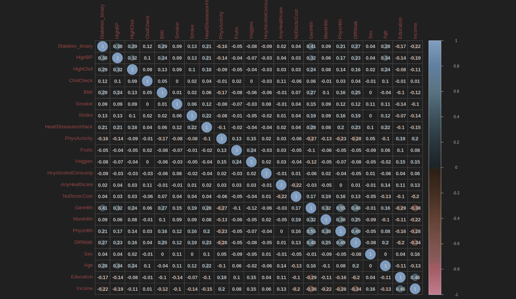

Correlation Matrix

We can see that some features have good correlation with diabetes binary. So we can explore more to find out more about our features and data.

## Feature Distribution diabetes vs no-diabetes

### BMI

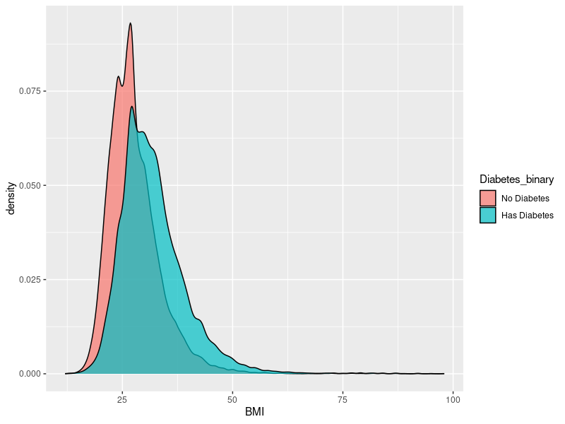

BMI Distributions

As we can see people with higher BMI are more likely to have Diabetes.We can use this feature to predict whether someone has diabetes or not.

### General Health

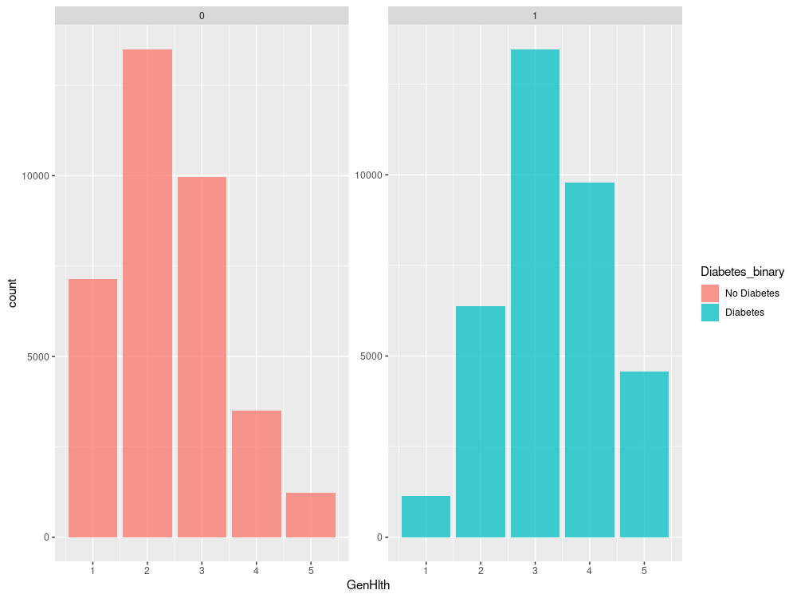

General Health Distributions

Is more shifted to right meaning people with diabetes have worse general health condition than others. people who answered they have poor health have a strong indication of diabetes. For example if we classify based on category 4,5 our accuracy can be good but this is a simple model with more complex models and more tuning we can predict the answer.